# NykkaRumbaoa_Simple Linear Regression

## Nykka's Python Project: Run simple linear regression

## Tasks:

- Provides insights about the company's sales and marketing practices.
- Explore the relationship between radio promotion budget and sales.
- Provide a clear understanding of the relationship between types of marketing campaigns and the revenue generated as a result of this investment.
- The dataset provided includes information about marketing campaigns across TV, radio, and social media, as well as how much revenue in sales was generated from these campaigns.
- Stakeholder will make decisions about where to focus future marketing resources.

## Step 1: Imports

### Import Python libraries and modules.

```python
# Import relevant Python libraries and modules
import pandas as pd
import matplotlib.pyplot as plt
import seaborn as sns

from statsmodels.formula.api import ols
import statsmodels.api as sm
```

### Load dataset into a DataFrame

- Dataset name `marketing_sales_data.csv`
- Numerical variables in the data are expressed in millions of dollars.

```python
# Load the dataset into a DataFrame and save in a variable
data = pd.read_csv("marketing_sales_data.csv")
```

## Step 2. Data Exploration

### Preview the first 10 rows of the data.

```python
# Display the first 10 rows of the data
data.head(10)
```

|  | TV | Radio | Social Media | Influencer | Sales |
| --- | --- | --- | --- | --- | --- |
| 0 | Low | 1.218354 | 1.270444 | Micro | 90.054222 |
| 1 | Medium | 14.949791 | 0.274451 | Macro | 222.741668 |
| 2 | Low | 10.377258 | 0.061984 | Mega | 102.774790 |
| 3 | High | 26.469274 | 7.070945 | Micro | 328.239378 |
| 4 | High | 36.876302 | 7.618605 | Mega | 351.807328 |
| 5 | High | 25.561910 | 5.459718 | Micro | 261.966812 |
| 6 | High | 37.263819 | 6.886535 | Nano | 349.861575 |
| 7 | Low | 13.187256 | 2.766352 | Macro | 140.415286 |
| 8 | High | 29.520170 | 2.333157 | Nano | 264.592233 |
| 9 | Low | 3.773287 | 0.135074 | Nano | 55.674214 |

#### **Question 1**: What do you observe about the different variables included in the data?

- Dataset includes:
  - TV promotion budget: "Low", "Medium", or "High"
  - Radio promotion budget
  - Social media promotion budget
  - Type of influencer: "Mega", "Macro", or "Micro", or "Nano"
    - Mega-influencers have over 1 million followers
    - macro-influencers have 100,000 to 1 million followers
    - micro-influencers have 10,000 to 100,000 followers
    - nano-influencers have fewer than 10,000 followers.
  - Sales accrued from the promotion

### Get the number of rows and the number of columns in the data.

```python
# Display number of rows, number of columns
data.shape
```

```
(572, 5)
```

#### **Question 2**: What do you observe about the number of rows and number of columns in the data?

- 572 rows (representing companies)
- 5 columns (representing 5 aspects of how service is promoted)
- I review dataset for missing values in the rows of the data.
- Missing values are not that meaningful when modeling the relationship between two variables.
- Get Booleans that indicate whether each value in the data is missing.
- Next, heck both columns and rows for missing values.

```python
# Step 1: Use .isna() to get booleans indicating if each value in the data is missing
data.isna()
```

|  | TV | Radio | Social Media | Influencer | Sales |
| --- | --- | --- | --- | --- | --- |
| 0 | False | False | False | False | False |
| 1 | False | False | False | False | False |
| 2 | False | False | False | False | False |
| 3 | False | False | False | False | False |
| 4 | False | False | False | False | False |
| ... | ... | ... | ... | ... | ... |
| 567 | False | False | False | False | False |
| 568 | False | False | False | False | False |
| 569 | False | False | False | False | False |
| 570 | False | False | False | False | False |
| 571 | False | False | False | False | False |

572 rows × 5 columns

```python
# Step 1: Use .isna() to get booleans indicating whether each value in the data is missing
# Step 2: Use .any(axis=1) to get booleans indicating whether there are any missing values along the columns in each row
data.isna().any(axis=1)
```

```
0      False
1      False
2      False
3      False
4      False
       ...
567    False
568    False
569    False
570    False
571    False
Length: 572, dtype: bool
```

```python
# Step 1: Use .isna() to get booleans indicating whether each value in the data is missing
# Step 2: Use .any(axis=1) to get booleans indicating whether there are any missing values along the columns in each row
# Step 3: Use .sum() to get the number of rows that contain missing values
data.isna().any(axis=1).sum()
```

```
3
```

#### **Question 3**: What do you observe about the number of rows containing missing values?

- I noticed that there are 3 rows contain missing values
- Three is not a lot considering the number of rows in dataset, so I can drop the missing values.

### Drop the rows that contain missing values.

- To clean the data, I will remove the missing values using the dropna function.
- This will make the data more usable for the analysis and regression.

```python
# Step 1: Use .dropna(axis=0) to drop the rows with missing data.
# Step 2: Update the DataFrame by reassign it to the result
data = data.dropna(axis=0)
```

```python
# Verify that the data does not contain any missing values
# Step 1. Use .isna() to check for missing data
# Step 2. Use .any(axis=1) check for missing values along the columns in each row
# Step 3. Use .sum() to get the number of rows that contain missing values
data.isna().any(axis=1).sum()
```

```
0
```

### Check model assumptions.

- To explore the relationship between radio promotion budget and sales, I will model the relationship using linear regression.
- I will check if the model assumptions for linear regression can be made.
- Some of the assumptions can be checked before the model is built.

### Create a plot of pairwise relationships in the data.

- Create a plot of pairwise relationship to visualize the relationships between variables in the data and check model assumptions.

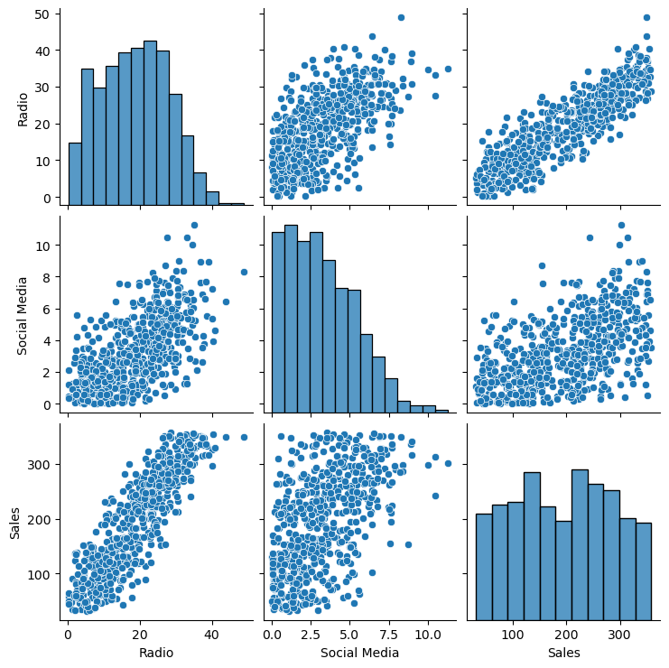

```python
# Use seaboarn to create plot of pairwise relationships
sns.pairplot(data)
```

#### **Question 4**: Is the assumption of linearity met?

- The scatter plot of `Sales` over `Radio`: appears to cluster around a line (this indicates a positive association between the two variables).
- Since the points cluster around a line, I will assume that the assumption of linearity is met.

## Step 3. Model Building

### Select only the columns that are needed for the model.

```python
# Select relevant columns
# Prepare for regression by saving resulting DataFrame in a new variable.
ols_data = data[["Radio", "Sales"]]
```

### Double check the first few rows of the new DataFrame.

```python
# Display first 10 rows of DataFrame
ols_data.head(10)
```

|  | Radio | Sales |
| --- | --- | --- |
| 0 | 1.218354 | 90.054222 |
| 1 | 14.949791 | 222.741668 |
| 2 | 10.377258 | 102.774790 |
| 3 | 26.469274 | 328.239378 |
| 4 | 36.876302 | 351.807328 |
| 5 | 25.561910 | 261.966812 |
| 6 | 37.263819 | 349.861575 |
| 7 | 13.187256 | 140.415286 |
| 8 | 29.520170 | 264.592233 |
| 9 | 3.773287 | 55.674214 |

### Create a linear regression formula for modeling the relationship between the 'Sales' and 'Radio'.

```python
# Write the linear regression formula
# Save it in a variable
ols_formula = "Sales ~ Radio"
```

### Use Ordinary Least Squares (OLS) approach for linear regression.

```python
# Use OLS
OLS = ols(formula = ols_formula, data = ols_data)
```

### Create a linear regression model for the data and fit the model to the data.

```python
# Fit the model to the data
# Save the fitted model in a variable
model = OLS.fit()
```

## Step 4. Results and Evaluation

### Get a summary of the results from the model.

```python
# Get summary
model.summary()
```

OLS Regression Results

| Dep. Variable: | Sales | R-squared: | 0.757 |
| --- | --- | --- | --- |
| Model: | OLS | Adj. R-squared: | 0.757 |
| Method: | Least Squares | F-statistic: | 1768. |
| Date: | Thu, 01 Feb 2024 | Prob (F-statistic): | 2.07e-176 |
| Time: | 21:34:44 | Log-Likelihood: | -2966.7 |
| No. Observations: | 569 | AIC: | 5937. |
| Df Residuals: | 567 | BIC: | 5946. |
| Df Model: | 1 |  |  |
| Covariance Type: | nonrobust |  |  |

|  | coef | std err | t | P>\|t\| | [0.025 | 0.975] |
| --- | --- | --- | --- | --- | --- | --- |
| Intercept | 41.5326 | 4.067 | 10.211 | 0.000 | 33.544 | 49.521 |
| Radio | 8.1733 | 0.194 | 42.048 | 0.000 | 7.791 | 8.555 |

| Omnibus: | 2.267 | Durbin-Watson: | 1.880 |
| --- | --- | --- | --- |
| Prob(Omnibus): | 0.322 | Jarque-Bera (JB): | 2.221 |
| Skew: | -0.102 | Prob(JB): | 0.329 |
| Kurtosis: | 2.772 | Cond. No. | 45.7 |

Notes:  
[1] Standard Errors assume that the covariance matrix of the errors is correctly specified.

### Analyze the summary.

- Based on that table, I can identify the coefficients that the model determined would generate the line of best fit.
- I will grab the y-intercept and the slope from the bottom portion of the table.

#### **Question 5**: What is the y-intercept?

- y-intercept = 41.5326.

#### **Question 6**: What is the slope?

- slope = 8.1733.

#### **Question 7**: What is the linear equation you would write to express the relationship between sales and radio promotion budget in the form of y = slope * x + y-intercept?

- sales = (8.1733 * radio promotion budget) + 41.5326

### Finish checking model assumptions.

Check the model assumptions to help confirm findings.

### Plot the OLS data with the best fit regression line.

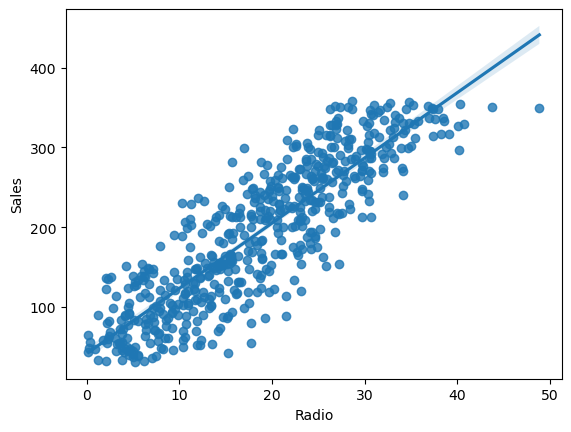

```python
# Use seaborn to plot the OLS data with the best fit regression line
sns.regplot(x = "Radio", y = "Sales", data = ols_data)
```

#### **Question 9**: What do you observe from the preceding regression plot?

- The regression plot above shows a linear relationship between the two variables (Sales and Radio) along with the best fit line.
- This confirms the assumption of linearity.

### Check the normality assumption.

First, I will get the residuals from the model.

```python
# Get the residuals from the model
residuals = model.resid
```

Then , I will plot the distribution of the residuals.

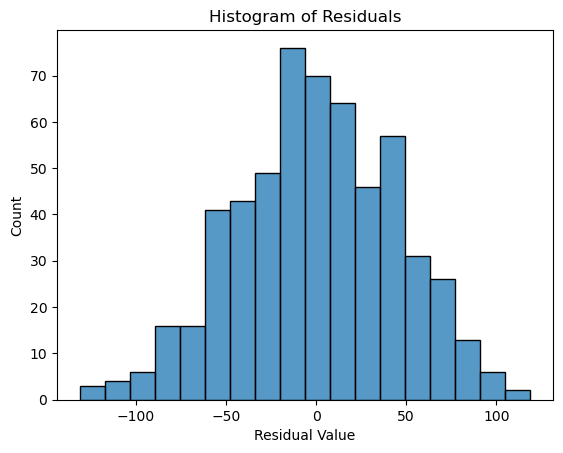

```python
# Create histogram of the distribution of the residuals
fig = sns.histplot(residuals)
fig.set_xlabel("Residual Value")
fig.set_title("Histogram of Residuals")
plt.show()
```

#### **Question 10**: Based on the preceding visualization, what do you observe about the distribution of the residuals?

- Based on the histogram, the distribution of the residuals is mostly normal.
- This indicates that the assumption of normality is likely met.

### Create a Q-Q plot to confirm the assumption of normality.

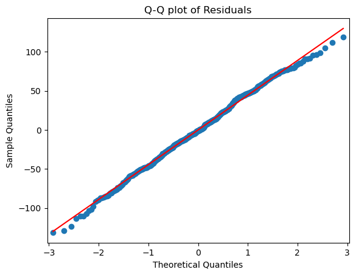

```python
# Create a Q-Q plot
sm.qqplot(residuals, line='s')
plt.title("Q-Q plot of Residuals")
plt.show()
```

#### **Question 11**: Is the assumption of normality met?

- The Q-Q plot shows that the points closely follow a straight diagonal line and is trending upward.
- This confirms that the normality assumption is met.

### Check the assumptions of independent observation and homoscedasticity.

First, I will get the fitted values from the model.

```python
# Get fitted values
fitted_values = model.predict(ols_data["Radio"])
```

Then, I will create a scatterplot of the residuals against the fitted values.

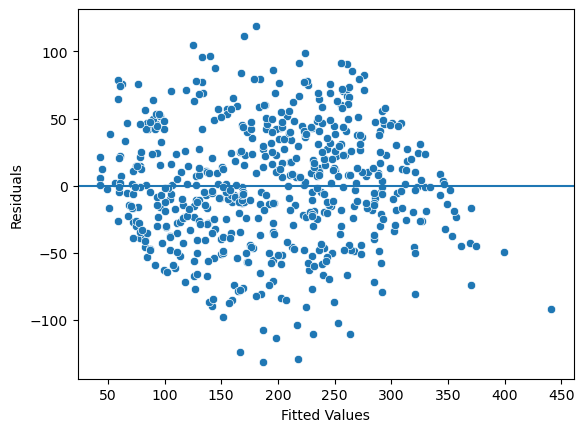

```python
# Create a scatterplot of residuals against fitted values
fig = sns.scatterplot(x=fitted_values, y=residuals)
fig.axhline(0)
fig.set_xlabel("Fitted Values")
fig.set_ylabel("Residuals")
plt.show()
```

#### **Question 12**: Are the assumptions of independent observation and homoscedasticity met?

- The scatterplot displays the points as a cloud-like resemblance that do not follow an explicit pattern.
- I can say that it appears that the independent observation assumption has not been violated.
- Since the residuals seemed to be randomly spaced out, the homoscedasticity assumption seems to be met.

## Findings

**Takeaways:**

- This project helps me to see that data visualizations and exploratory data analysis can be used to check if linear regression is an effective for modeling the relationship between two variables.
- The results of a linear regression model can be used to express the relationship between two variables.

**What results can be presented from this lab?**

- The result of this simple linear regression model shows the y-intercept is 41.5326 and the slope is 8.1733.
- This points to that a budget of 1 million dollars in radio promotion, can help a company's sales increase by 8.1733 million dollars on average.

**More Interpretations:**

- **Null hypothesis:**
  - There is no relationship between radio promotion budget and sales when the slope is zero.
- **Alternative hypothesis:**
  - There is a relationship between radio promotion budget and sales when the slope is not zero.
- **Result:**
  - I will reject the null hypothesis since there seemed to be a relationship between radio promotion budget and sales.
- The results are statistically significant: P-value of 0.000 is less than the common significance level of 0.05.
- There is a low probability of observing data as extreme or more extreme than this dataset when the null hypothesis is true.
- The slope of the line of best fit that resulted from the regression model is approximate and subject to uncertainty (not the exact value).
- The 95% confidence interval for the slope is from 7.791 to 8.555.
- There is a 95% probability that the interval [7.791, 8.555] contains the true value for the slope.

**How would you frame your findings to external stakeholders?**

- The regression analysis shows a notable relationship between radio promotion budget and sales, with a p-value of 0.000 and standard error of 0.194.
- For companies represented by this data, an increase in radio promotion budget could be associated an increase in sales.